# Communicating data analysis results

Summerschool Statistical Programming with R

## Topics of this lecture

- Communication
  - Workflow, package management
  - Nice tables with `gt_summary()`, `modelsummary`
  - Overview of graphics plus code
  - R Markdown functionality
- Selfstudy
- Presentation assignment
  - example

## Structure your R Markdown file

Set global options at the beginning of your R Markdown file, such as the example below.

```r
knitr::opts_chunk$set(message = FALSE,
                      warning = FALSE,
                      fig.width = 16/2,
                      fig.height = 9/2,
                      comment = "")
```

## Package management

Use the `pacman` package to manage packages. It will load the list of packages you provide and if you load a package that is not installed, `pacman` will start to install it.

```r
# Ensures the package "pacman" is installed
if (!require("pacman")) install.packages("pacman")

pacman::p_load(tidyverse,
               ggplot2,
               gtsummary,
               patchwork,
               GGally,
               boot)
```

## Give names to the code chunks

It is a good habit to give unique names to each code chunk. This allows you to easily find a specific code chunk, especially when your code is very long. See below an example of code chunk names.

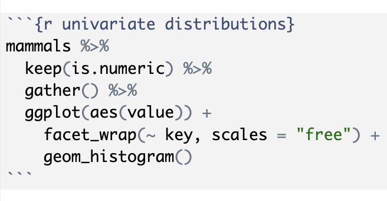

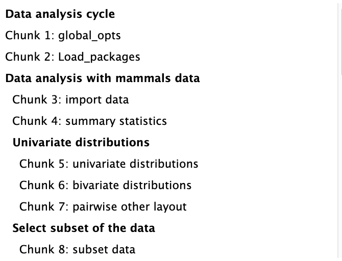

## Make nice tables `modelsummary`

[figure not shown]

https://modelsummary.com/index.html

## Make nice tables: `modelsummary`

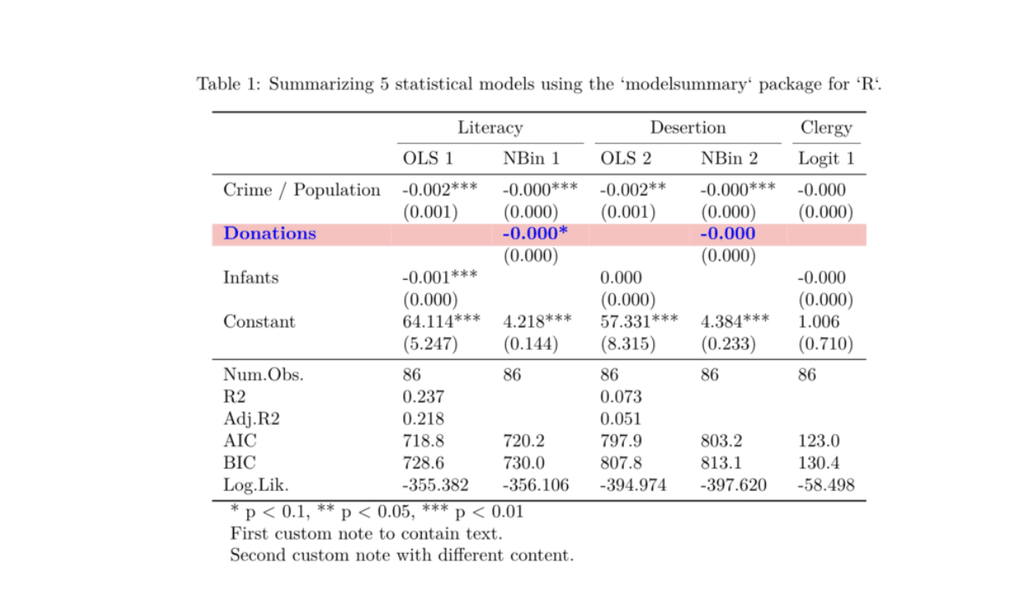

## Overview of graphics

This website gives an overview of graphs plus R code:

https://r-graph-gallery.com/

[figure not shown]

## Choosing an appropriate graph for your data

https://www.data-to-viz.com/

[figure not shown]

# R Markdown functionality

## R Markdown Journal Articles

Browse all availabe Journal templates for articles in File -> New File -> R Markdown:

[figure not shown]

## R Markdown themes (flatly, tango)

```r
---
  title: "Lab2a"
  subtitle: "Data manipulation with `tidyverse`"
  author "Laurence Frank"
  output:
    html_document:
    toc: true
    toc_depth: 3
    toc_float: true
    theme: flatly
    highlight: tango
---
```

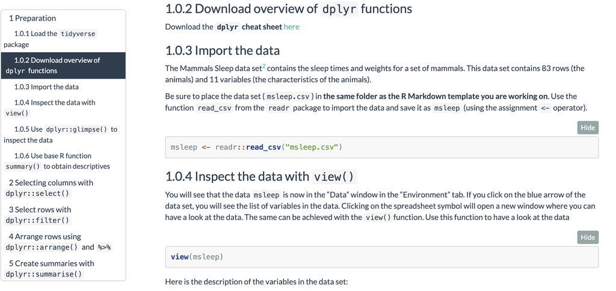

## R Markdown themes (journal, espresso)

```r
---
  title: "Lab2a"
  subtitle: "Data manipulation with `tidyverse`"
  author "Laurence Frank"
  output:
    html_document:
    toc: true
    toc_depth: 3
    toc_float: true
    theme: journal
    highlight: espresso
---
```

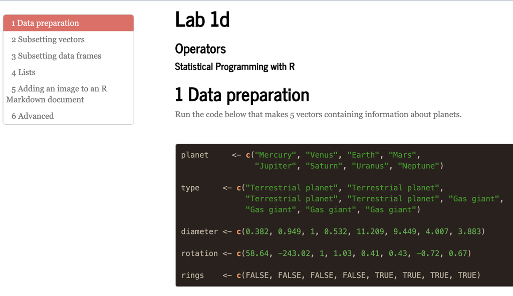

## Overview of themes in R Markdown

https://rpubs.com/ranydc/rmarkdown_themes

[figure not shown]

# Presentations with R Markdown

## ioslides

- **ioslides** is an R Markdown format for creating HTML presentations.
- It allows for interactive, visually appealing slides.
- Open a presentation with: File -> New File -> R Markdown -> Presentation

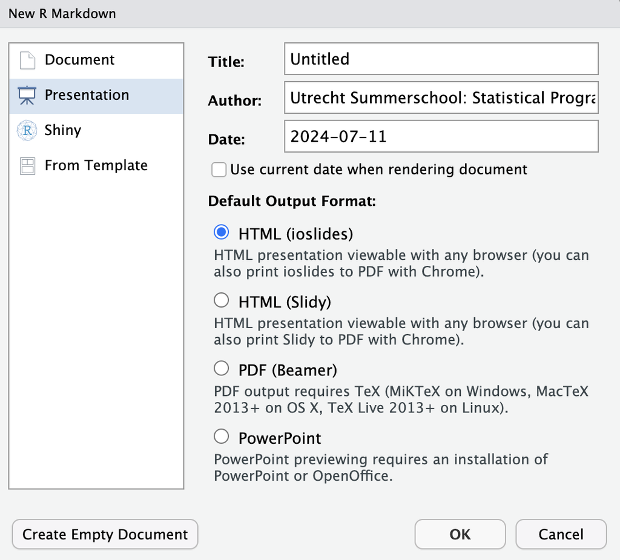

## Creating a Basic Slide

- Each slide starts with a second-level header (##).
  - `## Title of slide`
- A slide chapter starts with a first-level header (#)
  - `# New chapter`
- You can include text, R code, images, and tables, just as in a R Markdown file.

## Example ioslides: lecture style

[figure not shown]

## Custom css style

Custom CSS template for ioslides (available for you in the course materials for Friday).

You can use this css style file as follows in the YAML of your `ioslides` presentation:

```r
---
  title: "Linear model"
  subtitle: "Statistical Programming with R"
  author "Utrecht Summer School"
  output:
    ioslides_presentation:
      smaller: true
      css: custom.css

---
```

## Selfstudy: Quarto

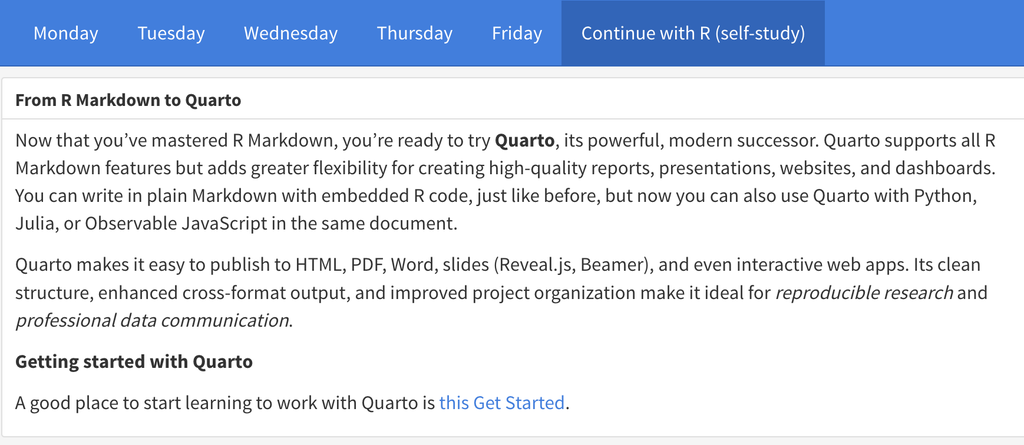

## Selfstudy: Shiny apps

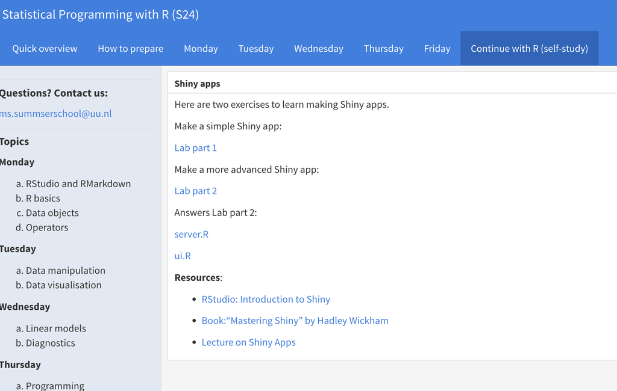

# Assignment

## Assignment: Data analysis cycle

Goal: Apply what you have learned in this course on a (new) data set and present your results with R Markdown.

Demo of RMarkdown file for data analysis cycle.

## Assignment: Data analysis cycle

Goal: Apply what you have learned in this course on a (new) data set and present your results with R Markdown.

1. Choose a data set. Data sets are provided (see tab “Friday” of the course manual), but you can also work on your own data.
2. Prepare a presentation in RMarkdown with slides (see course materials tab “Friday” for template) or a HTML report (use the R Markdown template files for the labs).
3. Work in pairs/groups if you like.
4. Time to prepare: morning session (09:30 - 12:00) plus afternoon (13:00 - 14:30).
5. The assignment should address the key stages of the Data Analysis Cycle: importing data, tidying or transforming data, visualising data, modelling, interpreting and communicating the results.